# Modelling the distribution of biodiversity under global climate change

Jorge Assis, PhD // Nord University, Norway // biodiversityDS, Centre of Marine Sciences, Portugal

## Model evaluation

## Model evaluation with random cross-validation

biodiversityDS .

Random cross-validation is a method to evaluate the performance of a model by splitting the data into training and testing sets multiple times. This approach can generate test datasets with low level of independence.

```r
# read occurrence records (presences) and transform to spatial object
library(terra)
presences <- read.table("../Data/Text delimited/species_presence_records.csv", sep = ";", header = TRUE)
presences <- vect(presences, geom = c("Lon", "Lat"), crs = "EPSG:4326")
```

S6 // Performance of Species Distribution Models

biodiversityDS .

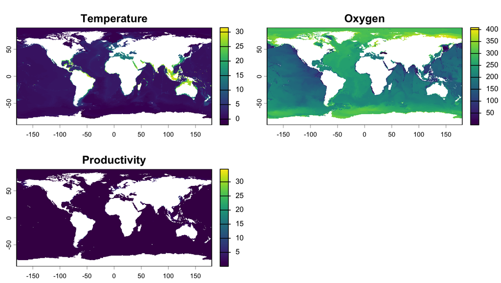

```r
# download layers for present conditions
variables <- list(var1 = c("thetao", "mean", "depthmean"), var2 = c("o2", "mean", "depthmean"),
    var3 = c("phyc", "mean", "depthmean"))
environmentalLayers <- download_multiple_layers(variables = variables, experiment = c("baseline"),
    decade = c(2010))
names(environmentalLayers) <- c("Temperature", "Oxygen", "Productivity")
# plot layers
plot(environmentalLayers, axes = TRUE)
```

S6 // Performance of Species Distribution Models

biodiversityDS .

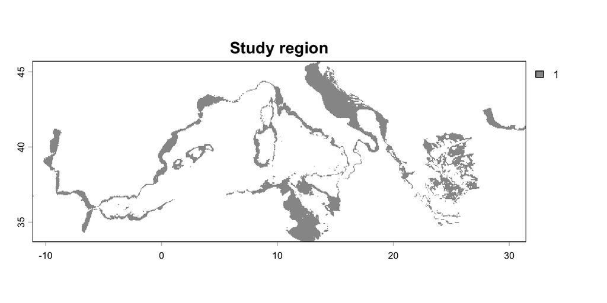

```r
# develop a study region layer
myStudyRegion <- studyRegion(rasterLayers=environmentalLayers, # SpatRaster of layers
                             presences=presences, # presence records
                             distanceThreshold=200000, # distance from records in meters
                             topographyLayer = "../Data/Raster data/Bathymetry.tif", # bathymetry layer
                             verticalPref=c(-15,-300)) # known vertical distribution
# inspect the study region layer
plot(myStudyRegion, main="Study region", col="#979797", axes=TRUE)
```

S6 // Performance of Species Distribution Models

biodiversityDS .

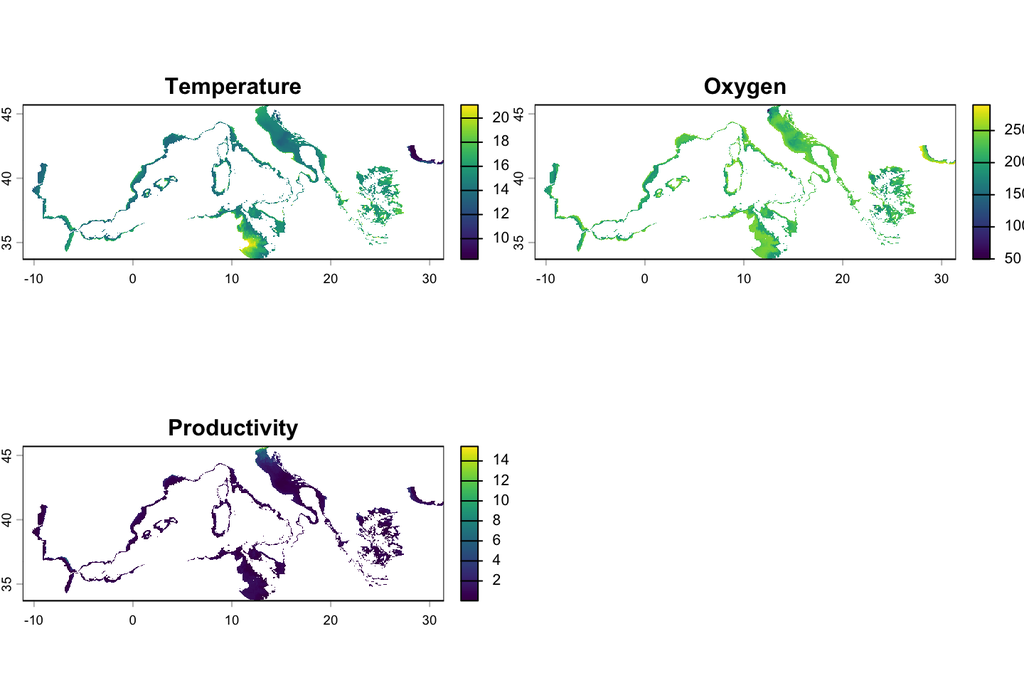

```r
# crop the environmental layers to the extent of the study region
environmentalLayers <- crop(environmentalLayers, myStudyRegion)
# mask the environmental layers with the study region
environmentalLayers <- mask(environmentalLayers, myStudyRegion)
# plot the masked environmental layers
plot(environmentalLayers, axes = TRUE)
```

S6 // Performance of Species Distribution Models

biodiversityDS .

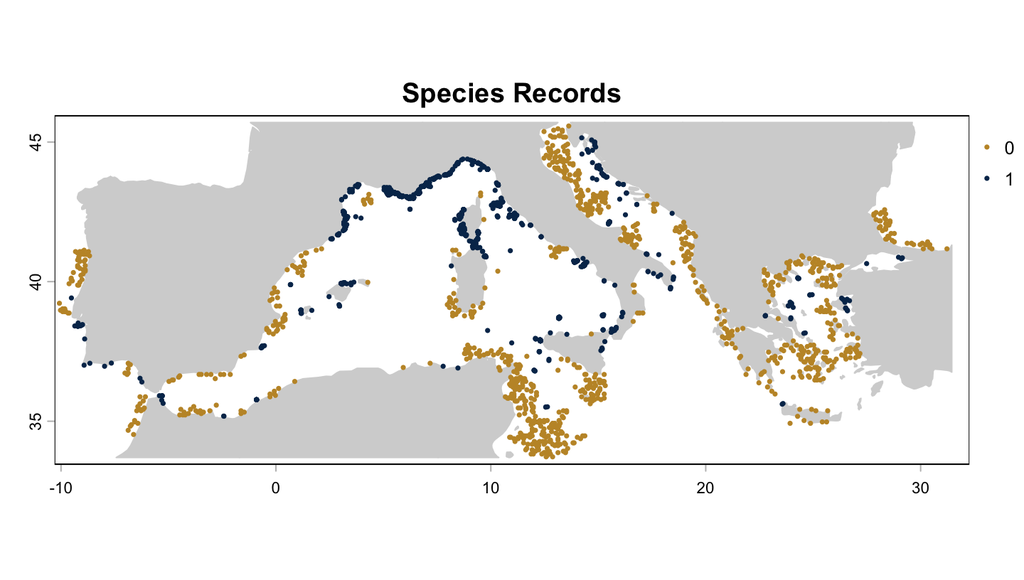

```r
# generate pseudo-absences and combine presences and absences into a unique object
absences <- pseudoAbsences(rasterLayers = environmentalLayers, presences = presences, n = 1000)
presences$PA <- 1
absences$PA <- 0
records <- rbind(absences, presences)
# generate a landmass for representation
landmass <- vect("../Data/Vector data/Landmass/landmass.shp")
landmassMed <- crop(landmass, myStudyRegion)
# plot records
plot(landmassMed, main = "Species Records", col = "#D4D4D4", border = "#D4D4D4", axes = TRUE)
plot(records, y = "PA", col = c("#c29431", "#043259"), pch = 16, cex = 0.5, add = TRUE)
```

S6 // Performance of Species Distribution Models

biodiversityDS .

```r
# extract environmental values and make an object with all information to model
modelData <- generateModelData(records, environmentalLayers, method = "random", bootstrapRounds = 10,
    paMinimum = 100, paRatio = 1)
```

S6 // Performance of Species Distribution Models

biodiversityDS .

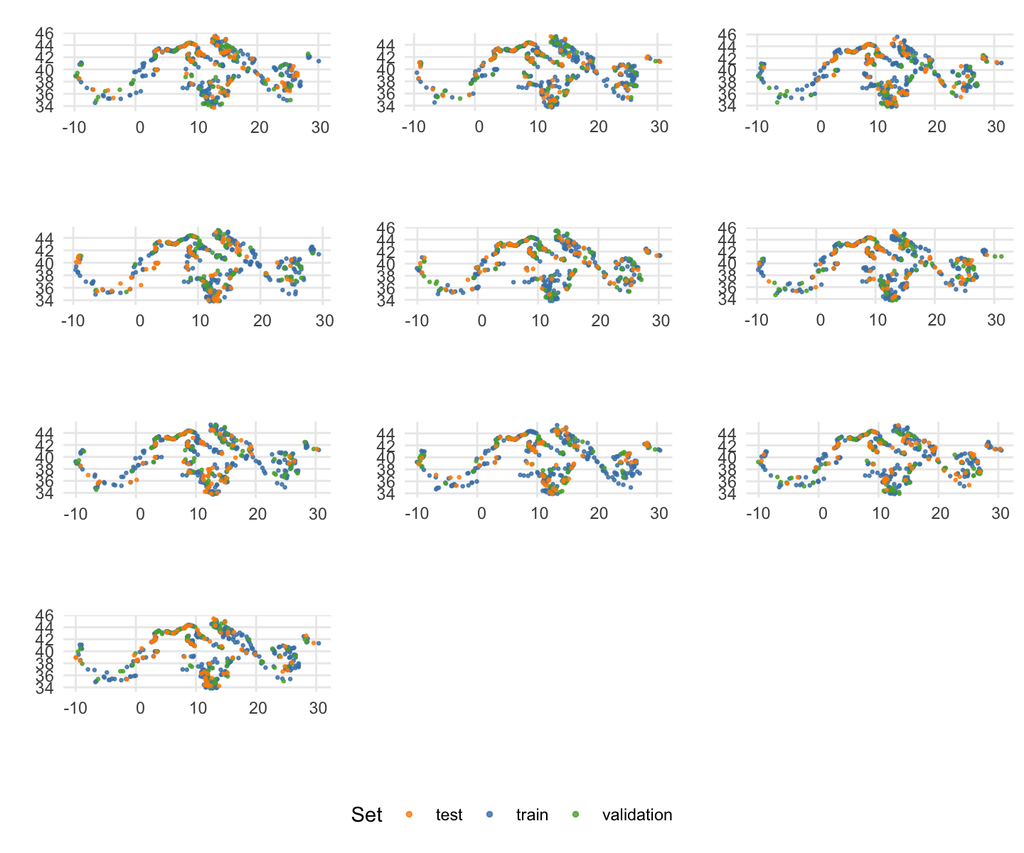

```r
modelData$plotDatasets
```

S6 // Performance of Species Distribution Models

biodiversityDS .

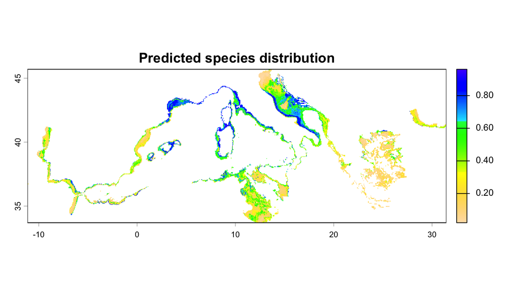

```r
# fit a brt model to the dataset
model <- trainModel(modelData, algorithm = "brt")
# predict the distribution with the model over a raster stack
prediction <- predictModel(model = model, newData = environmentalLayers)
# map the predicted distribution
plot(prediction$rasterLayer, main = "Predicted species distribution", col = rev(topo.colors(100)))
```

S6 // Performance of Species Distribution Models

biodiversityDS .

```r
# inspect model performance
model$performance
```

| dataset | index | threshold | auc | auc.prg | sensitivity | specificity | boyce | tss | prevalence.obs | prevalence.pred |
| --- | --- | --- | --- | --- | --- | --- | --- | --- | --- | --- |
| test | Average | 0.2309560 | 0.8498000 | 0.7295486 | 0.9429000 | 0.4542900 | 0.7994000 | 0.3971900 | 0.5 | 0.7442800 |
| test | sd | 0.0665414 | 0.0564521 | 0.1246629 | 0.0000000 | 0.0975386 | 0.0789757 | 0.0975386 | 0.0 | 0.0487733 |
| validation | Average | 0.4455540 | 0.8275000 | 0.6692040 | 0.8270300 | 0.7351500 | 0.7895000 | 0.5621800 | 0.5 | 0.5459400 |
| validation | sd | 0.1300028 | 0.0462775 | 0.0951765 | 0.0884439 | 0.1025720 | 0.0718892 | 0.0951797 | 0.0 | 0.0831049 |
| train | Average | 0.5210160 | 0.9377000 | 0.9027064 | 0.8600000 | 0.8878800 | 0.9685000 | 0.7478800 | 0.5 | 0.4860600 |
| train | sd | 0.0706189 | 0.0065328 | 0.0125186 | 0.0496828 | 0.0515274 | 0.0221873 | 0.0240948 | 0.0 | 0.0491584 |

S6 // Performance of Species Distribution Models

## Model evaluation with blocks cross-validation

biodiversityDS .

Blocks cross-validation is a method to evaluate the performance of a model by splitting the data into training and testing sets multiple times. This approach can generate test datasets with high level of independence.

```r
# Inspect spatial autocorrelation in the layers
sacAnalysis <- sac(environmentalLayers = environmentalLayers)
sacAnalysis$distance
```

```
## [1] 66.66667
```

S6 // Performance of Species Distribution Models

biodiversityDS .

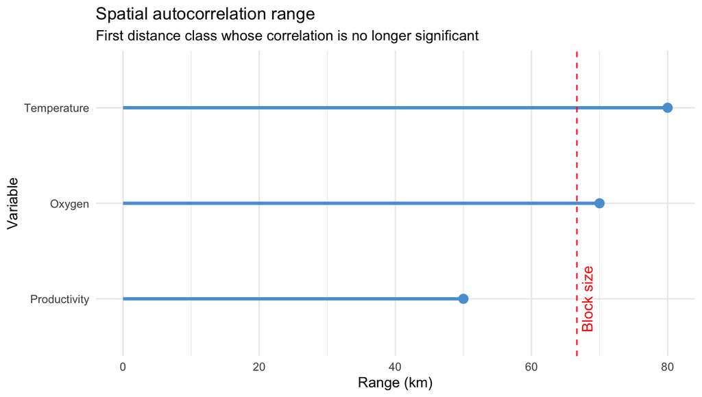

```r
# Inspect spatial autocorrelation in the layers
sacAnalysis$plot
```

S6 // Performance of Species Distribution Models

biodiversityDS .

```r
# extract environmental values and make an object with all information to model
modelData <- generateModelData(records, environmentalLayers, method = "blocks", bootstrapRounds = 10,
    paMinimum = 100, paRatio = 1, sacDist = sacAnalysis$distance)
```

S6 // Performance of Species Distribution Models

biodiversityDS .

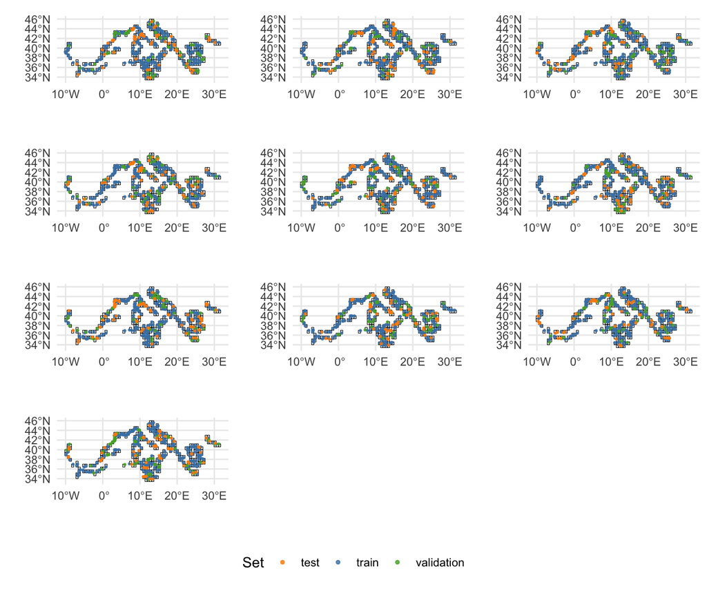

```r
# inspect the data partitioning
modelData$plotDatasets
```

S6 // Performance of Species Distribution Models

biodiversityDS .

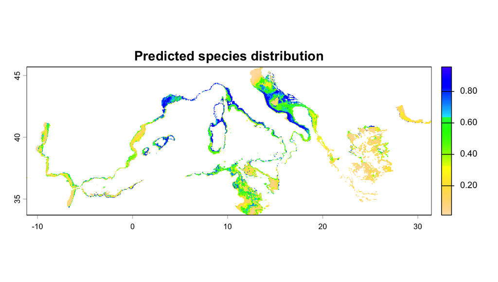

```r
# fit a brt model to the dataset
model <- trainModel(modelData, algorithm = "brt")
# predict the distribution with the model over a raster stack
prediction <- predictModel(model = model, newData = environmentalLayers)
# map the predicted distribution
plot(prediction$rasterLayer, main = "Predicted species distribution", col = rev(topo.colors(100)))
```

S6 // Performance of Species Distribution Models

biodiversityDS .

```r
# inspect model performance
model$performance
```

| dataset | index | threshold | auc | auc.prg | sensitivity | specificity | boyce | tss | prevalence.obs | prevalence.pred |
| --- | --- | --- | --- | --- | --- | --- | --- | --- | --- | --- |
| test | Average | 0.2358440 | 0.8111000 | 0.6510958 | 0.9431000 | 0.4428600 | 0.7798000 | 0.3859600 | 0.5 | 0.7501100 |
| test | sd | 0.1329988 | 0.0835310 | 0.1557639 | 0.0044996 | 0.1879472 | 0.1063504 | 0.1859246 | 0.0 | 0.0950269 |
| validation | Average | 0.4371920 | 0.7936000 | 0.6097493 | 0.8314500 | 0.7102200 | 0.6051000 | 0.5416700 | 0.5 | 0.5606100 |
| validation | sd | 0.1568932 | 0.0809598 | 0.1636290 | 0.1149845 | 0.1805943 | 0.2210226 | 0.1384940 | 0.0 | 0.1346285 |
| train | Average | 0.5289040 | 0.9441000 | 0.9107358 | 0.8802100 | 0.8911300 | 0.9681000 | 0.7713400 | 0.5 | 0.4945700 |
| train | sd | 0.0316326 | 0.0139718 | 0.0250133 | 0.0336910 | 0.0205021 | 0.0133204 | 0.0407511 | 0.0 | 0.0190335 |

S6 // Performance of Species Distribution Models

biodiversityDS .

### Challenge 6.1

The main objective of this challenge is to **fit** a BRT model and assess its **predictive performance** with **random cross-validation**.

**Packages, data and functions to accomplish the challenge:**

**Files to use**  
**Functions to use**  
library  
download_multiple_layers  
rast  
plot  
studyRegion  
pseudoAbsences  
crop  
mask  
generateModelData  
trainModel  
predictModel

S5 // Developing Species Distribution Models in R

biodiversityDS .

### Challenge 6.2

The main objective of this challenge is to **fit** a BRT model and assess its **predictive performance** with **blocks cross-validation**.

**Packages, data and functions to accomplish the challenge:**

**Files to use**  
**Functions to use**  
library  
download_multiple_layers  
rast  
plot  
studyRegion  
pseudoAbsences  
crop  
mask  
generateModelData  
trainModel  
predictModel

S5 // Developing Species Distribution Models in R

## Variable relative importance

biodiversityDS .

Inspecting relative importance of variables to assess their potential ecological role in the models.

```r
# get the variable relative contribution
modelVarContrib <- variableContribution(model, rasterLayers = environmentalLayers)
```

S6 // Performance of Species Distribution Models

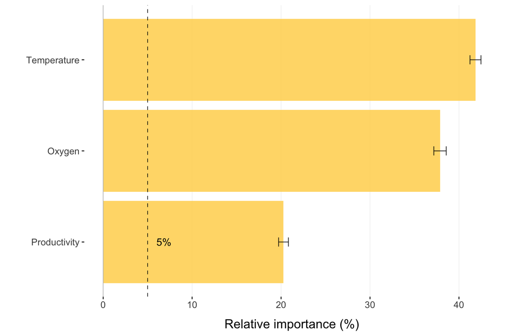

```r
# plot the variable relative contribution
modelVarContrib$plot
```

S6 // Performance of Species Distribution Models

## Response curves

biodiversityDS .

Inspecting response curves of variables to assess their potential ecological role in the models.

```r
# list the available layers
names(environmentalLayers)
```

```
## [1] "Temperature"  "Oxygen"       "Productivity"
```

S6 // Performance of Species Distribution Models

biodiversityDS .

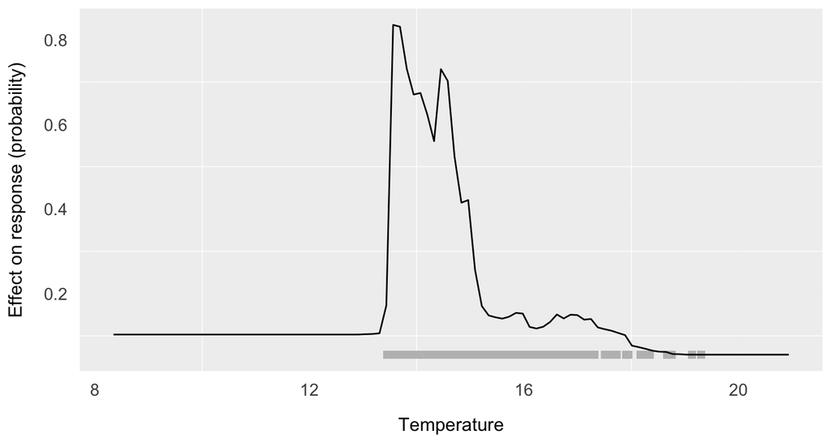

```r
# inspect the partial dependence plots
partialPlotTemperature <- partialPlot(model, modelData, variablePlot = "Temperature")
partialPlotTemperature$partialPlot
```

S6 // Performance of Species Distribution Models

biodiversityDS .

The response curves provide important information on the potential physiological thresholds.

```r
# inspect the potential physiological tipping points
partialPlotTemperature$tippingPoints
```

|  | maxRateChangeThreshold | extremeThreshold | usedThreshold | usedThresholdQ95 |
| --- | --- | --- | --- | --- |
| 95% | 13.43433 | 19.28583 | 19.30199 | 17.70185 |

S6 // Performance of Species Distribution Models

biodiversityDS .

### Challenge 6.3

The main objective of this challenge is to **evaluate** a model by inspecting variable relative contribution.

**Packages, data and functions to accomplish the challenge:**

**Files to use**  
**Functions to use**  
library  
download_multiple_layers  
rast  
plot  
studyRegion  
pseudoAbsences  
crop  
mask  
generateModelData  
trainModel  
variableContribution

S5 // Developing Species Distribution Models in R

biodiversityDS .

### Challenge 6.4

The main objective of this challenge is to **evaluate** a model by inspecting response curves.

**Packages, data and functions to accomplish the challenge:**

**Files to use**  
**Functions to use**  
library  
download_multiple_layers  
rast  
plot  
studyRegion  
pseudoAbsences  
crop  
mask  
generateModelData  
trainModel  
partialPlot

S5 // Developing Species Distribution Models in R

## Model Reclassification

## Minimum training presence threshold

biodiversityDS .

Minimum training presence threshold is the lowest predicted value associated with at least 90% of observed presence records. This threshold is commonly used to reclassify the predicted distribution into binary presence/absence.

```r
# read occurrence records (presences) and transform to spatial object
library(terra)
presences <- read.table("../Data/Text delimited/species_presence_records.csv", sep = ";", header = TRUE)
presences <- vect(presences, geom = c("Lon", "Lat"), crs = "EPSG:4326")
```

S6 // Performance of Species Distribution Models

biodiversityDS .

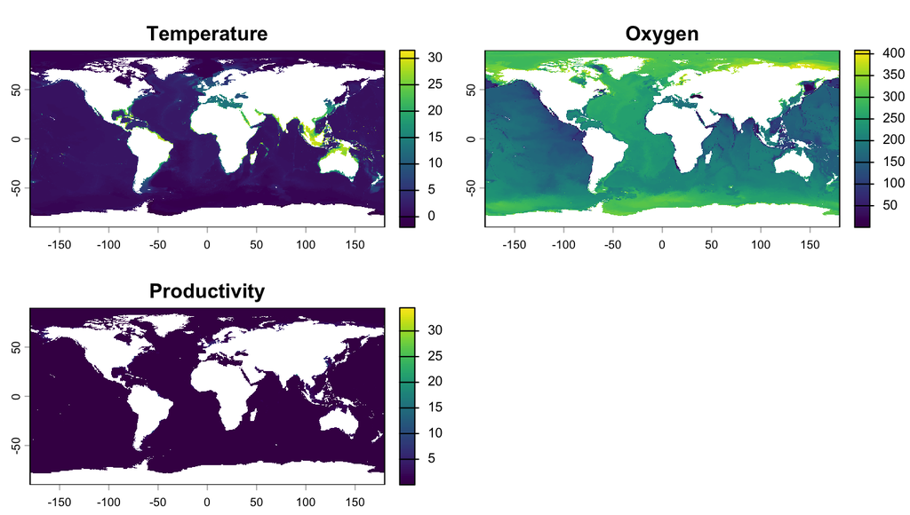

```r
# download layers for present conditions
variables <- list(var1 = c("thetao", "mean", "depthmean"), var2 = c("o2", "mean", "depthmean"),
    var3 = c("phyc", "mean", "depthmean"))
environmentalLayers <- download_multiple_layers(variables = variables, experiment = c("baseline"),
    decade = c(2010))
# change for friendly names
names(environmentalLayers) <- c("Temperature", "Oxygen", "Productivity")
# plot layers
plot(environmentalLayers, axes = TRUE)
```

S6 // Performance of Species Distribution Models

biodiversityDS .

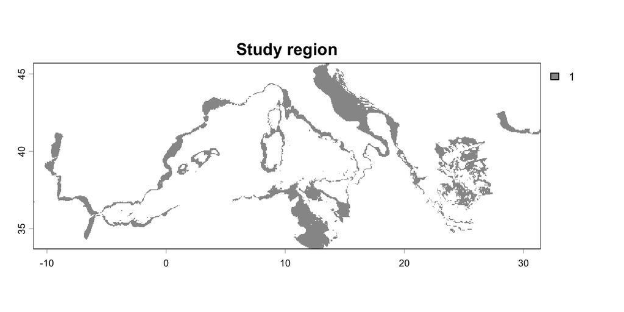

```r
# develop a study region layer
myStudyRegion <- studyRegion(rasterLayers=environmentalLayers, # SpatRaster of layers
                             presences=presences, # presence records
                             distanceThreshold=200000, # distance from records in meters
                             topographyLayer = "../Data/Raster data/Bathymetry.tif", # bathymetry layer
                             verticalPref=c(-15,-300)) # known vertical distribution
# inspect the study region layer
plot(myStudyRegion, main="Study region", col="#979797", axes=TRUE)
```

S6 // Performance of Species Distribution Models

biodiversityDS .

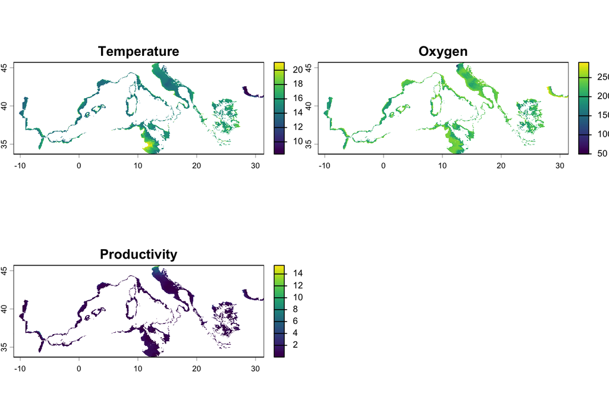

```r
# crop the environmental layers to the extent of the study region
environmentalLayers <- crop(environmentalLayers, myStudyRegion)
# mask the environmental layers with the study region
environmentalLayers <- mask(environmentalLayers, myStudyRegion)
# plot the masked environmental layers
plot(environmentalLayers, axes = TRUE)
```

S6 // Performance of Species Distribution Models

biodiversityDS .

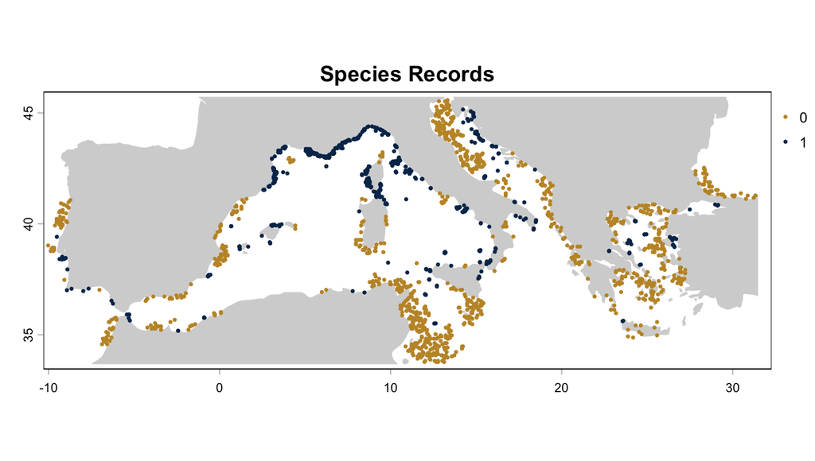

```r
# generate pseudo-absences and combine presences and absences into a unique object
absences <- pseudoAbsences(rasterLayers = environmentalLayers, presences = presences, n = 1000)
presences$PA <- 1
absences$PA <- 0
records <- rbind(absences, presences)
# generate a landmass for representation
landmass <- vect("../Data/Vector data/Landmass/landmass.shp")
landmassMed <- crop(landmass, myStudyRegion)
# plot records
plot(landmassMed, main = "Species Records", col = "#D4D4D4", border = "#D4D4D4", axes = TRUE)
plot(records, y = "PA", col = c("#c29431", "#043259"), pch = 16, cex = 0.5, add = TRUE)
```

S6 // Performance of Species Distribution Models

biodiversityDS .

```r
# Inspect spatial autocorrelation in the layers
sacAnalysis <- sac(environmentalLayers = environmentalLayers)
sacAnalysis$distance
```

```
## [1] 66.66667
```

S6 // Performance of Species Distribution Models

biodiversityDS .

```r
# extract environmental values and make an object with all information to model
modelData <- generateModelData(records, environmentalLayers, method = "blocks", bootstrapRounds = 10,
    sacDist = sacAnalysis$distance, paMinimum = 100, paRatio = 1)
```

S6 // Performance of Species Distribution Models

biodiversityDS .

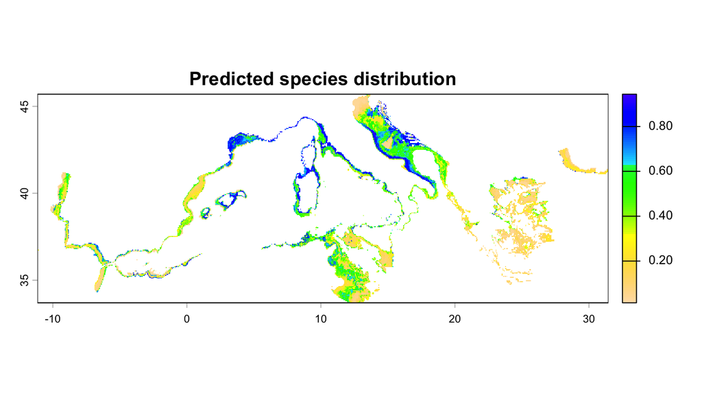

```r
# fit a brt model to the dataset
model <- trainModel(modelData, algorithm = "brt")
# predict the distribution with the model over a raster stack
prediction <- predictModel(model = model, newData = environmentalLayers)
# map the predicted distribution
plot(prediction$rasterLayer, main = "Predicted species distribution", col = rev(topo.colors(100)))
```

S6 // Performance of Species Distribution Models

biodiversityDS .

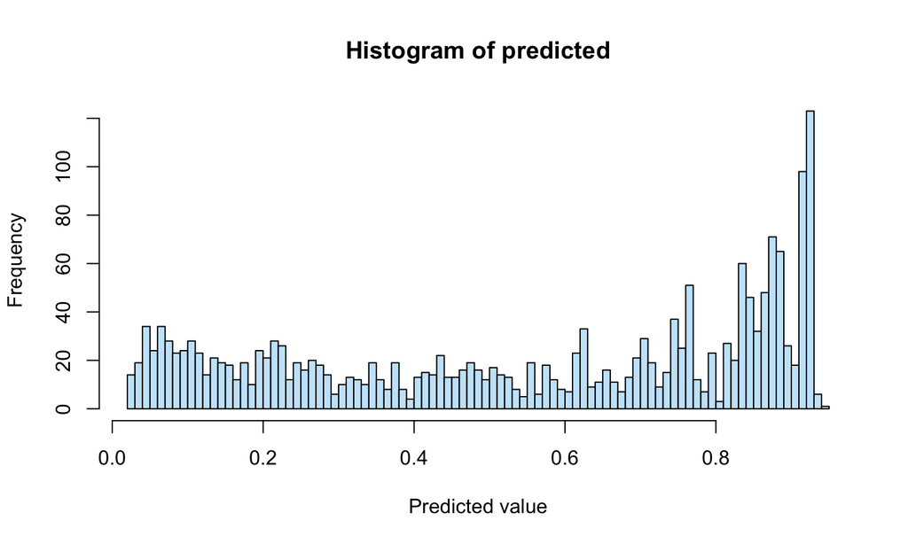

```r
# reclass the predicted distribution into binary presence/absence using the minimum train
# threshold
observed <- records$PA
predicted <- extract(prediction$rasterLayer, records, ID = FALSE)[, 1]

# inspect the predicted values at observed sites
hist(predicted, xlab = "Predicted value", col = "#C8E6FA", breaks = 100)
```

S6 // Performance of Species Distribution Models

biodiversityDS .

```r
# infer the minimum training presence threshold
performance <- modelPerformance(observed, predicted, index = "minimumTrain90")
performance
```

```
##   criteria threshold   auc   auc.prg omission.rate sensitivity specificity
## 1      P10   0.61375 0.946 0.9206792        0.0982      0.9018       0.875
##   prop.correct  Kappa     aicc deviance boyce    tss prevalence.obs
## 1     0.888251 0.7766 1198.684 1194.677 0.984 0.7768      0.4944388
##   prevalence.pred
## 1          0.5091
```

S6 // Performance of Species Distribution Models

biodiversityDS .

```r
# apply the minimum training presence threshold
threshold <- performance$threshold
threshold
```

```
## [1] 0.61375
```

```r
rclmat <- data.frame(from = c(0, threshold), to = c(threshold, 1), becomes = c(0, 1))
rclmat
```

```
##      from      to becomes
## 1 0.00000 0.61375       0
## 2 0.61375 1.00000       1
```

S6 // Performance of Species Distribution Models

biodiversityDS .

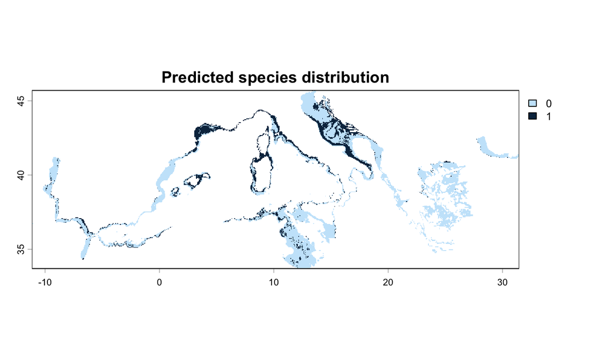

```r
# reclassify prediction into presence/absence
predictionPresentReclass <- classify(prediction$rasterLayer, rclmat)

# plot the predicted distribution reclassified into presence/absence
plot(predictionPresentReclass, main = "Predicted species distribution", col = c("#C8E6FA", "#0c2f4d"))
```

S6 // Performance of Species Distribution Models

biodiversityDS .

### Challenge 6.5

The main objective of this challenge is to **reclass** the predicted distribution into binary presence/absence.

**Packages, data and functions to accomplish the challenge:**

**Files to use**  
**Functions to use**  
library  
download_multiple_layers  
rast  
plot  
studyRegion  
pseudoAbsences  
crop  
mask  
generateModelData  
trainModel

S6 // Performance of Species Distribution Models